# Reproducible Research: Peer Assessment 1

## Loading and preprocessing the data

### 1. Load the data (i.e.read.csv())

```r
if(!file.exists('activity.csv')){
        unzip('activity.zip')
}
activity_dt <- read.csv('activity.csv')
```

### 2. Process/transform the data (if neccessary) into a format duitable for your analysis

## What is mean total number of steps taken per day ?

### 1. Calculate the total number of steps taken per day

```r
DT<-data.table(activity_dt)
StepsByDay<-DT[,sum(na.omit(steps)),by=.(date)]
setnames(StepsByDay,c("Date","TotalStepsPerDay"))
```

### 2. Make a histogram of total number of steps taken each day.

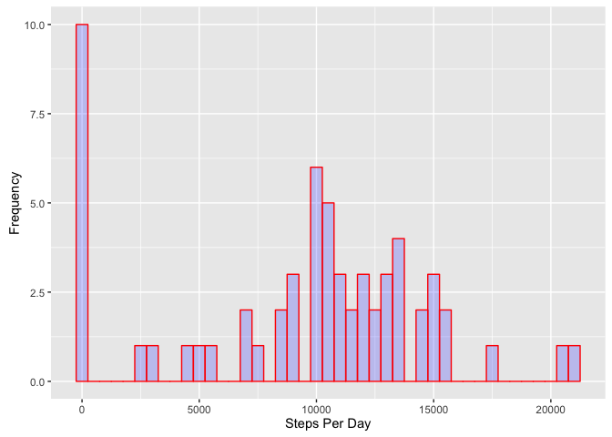

```r
StepsByDay[,qplot(TotalStepsPerDay,
        xlab='Steps Per Day',
        ylab='Frequency',
        geom="histogram",
        binwidth=500,
        alpha=I(.2),
        fill=I("blue"),
        col=I("red")
        )]
```

### 3. Calculate and report the mean and median of the total number of steps taken per day.

```r
out<-StepsByDay[,.(mean(na.omit(TotalStepsPerDay)),median(na.omit(TotalStepsPerDay)))]
```

Mean: 9354.2295082

Median: 10395

## What is the average daily activity pattern ?

### 1. Make a time series plot(i.e. type = “1”) of the 5-minute interval (x-axis) and the average number of steps taken, averaged across all days (y-axis)

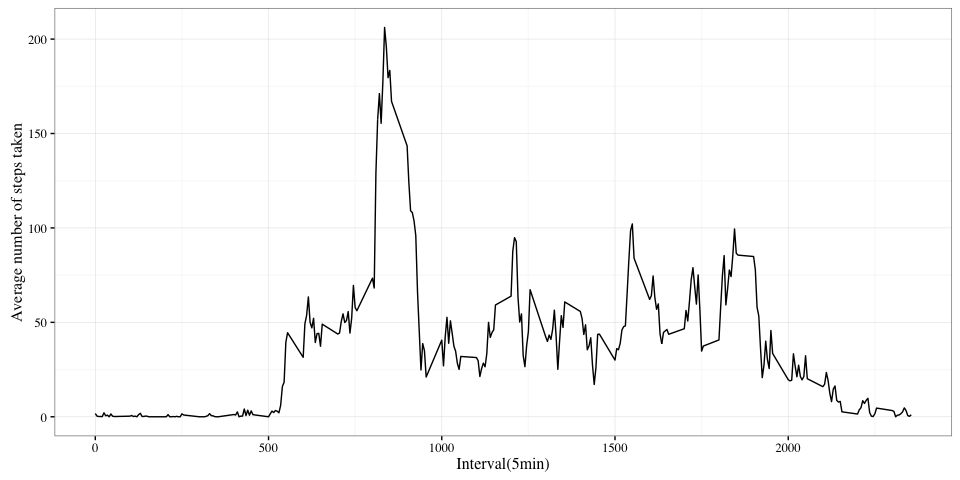

```r
avgStepsByInterval<-DT[,mean(na.omit(steps)),by=.(interval)]
setnames(avgStepsByInterval,c("interval","avgStepsTakenPerInterval"))
ggplot(avgStepsByInterval,
        aes(x = interval, y = avgStepsTakenPerInterval)) +
        geom_line() +
        xlab("Interval(5min)") +
        ylab("Average number of steps taken") +
        theme_bw(base_family="Times")
```

### 2. Which 5-minute interval, on average across all the days in the dataset, contains the maximum number of steps?

```r
MaxSteps<-which.max(avgStepsByInterval$avgStepsTakenPerInterval)
c<-avgStepsByInterval[MaxSteps,interval]
IntervalWithMaxSteps<-paste(str_sub(c,0,nchar(c)-2),':',str_sub(c,nchar(c)-1,nchar(c)),sep="")
```

Time With Max Steps Taken: 8:35

## Inputing Missing Values

### 1. Calculate and Report number of missing values in the dataset (i.e. the total number of Rows with NAs)

```r
RowsWithNAs<-md.pattern(activity_dt)
```

```
      date interval steps
15264    1        1     1    0
 2304    1        1     0    1
         0        0  2304 2304
```

The output tells us that 15264 cases are complete and 2304 samples miss Steps measurement.

### 3. Create a new dataset that is equal to the original dataset but with the missing data filled in.

```r
tempDT <- mice(activity_dt, m=5, maxit=5, meth='mean',seed=500)
```

```r
completeDT <- complete(tempDT,1)
```

Check distribution of orginal and imputed data using xyplot plot.

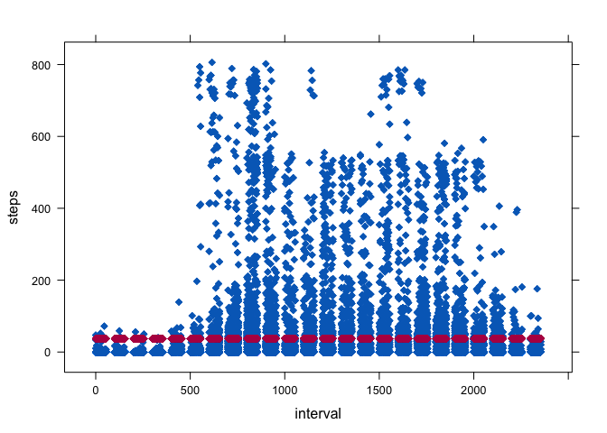

```r
library(lattice)
xyplot(tempDT,steps ~ interval,pch=18,cex=1)
```

### 4. Make a histogram of the total number of steps taken each day and Calculate and report the mean and median total number of steps taken per day. Do these values differ from the estimates from the first part of the assignment? What is the impact of imputing missing data on the estimates of the total daily number of steps?

[figure not shown]

```r
DTImputed<-data.table(completeDT)
StepsByDayImputed<-DTImputed[,sum(na.omit(steps)),by=(as.Date(date,,'%Y-%m-%d'))]
setnames(StepsByDayImputed,c("Date","TotalStepsPerDay"))
```

```r
out<-StepsByDayImputed[,.(mean(na.omit(TotalStepsPerDay)),median(na.omit(TotalStepsPerDay)))]
```

## Are there differences in activity patterns between weekdays and weekends?

## 1.Create a new factor variable in the dataset with two levels – “weekday” and “weekend” indicating whether a given date is a weekday or weekend day.

```r
DTImputed[,dayOfWeek:=ifelse(wday(as.Date(date,'%Y-%m-%d')) %in% c(0,6), 'weekend', 'weekday')]
```

## 2. Make a panel plot

```r
avgStepsByDayIntervalImputed<-DTImputed[,AvgSteps:=mean(steps),by=list(interval,dayOfWeek)]
```

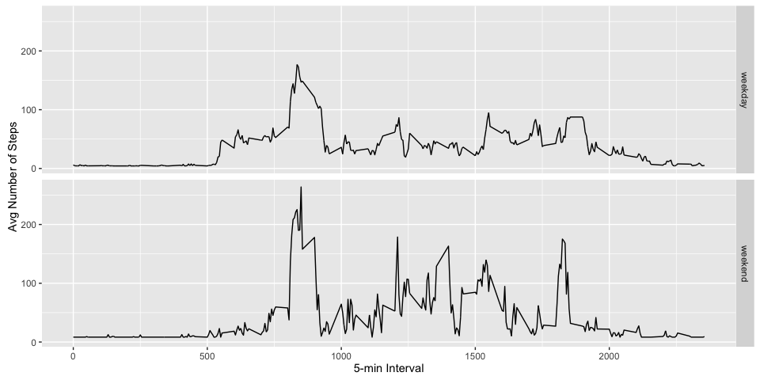

```r
ggplot(avgStepsByDayIntervalImputed,aes(interval,AvgSteps)) +
geom_line() +
facet_grid(dayOfWeek ~ .) +
xlab("5-min Interval") +
ylab("Avg Number of Steps")
```